# NOAA Database - Severe Storm Analysis

Anil Kumar R

5/6/2017

## Synopsis

Storms and other severe weather events can cause both public health and economic problems for communities and municipalities. Many severe events can result in fatalities, injuries, and property damage, and preventing such outcomes to the extent possible is a key concern.

This project involves exploring the U.S. National Oceanic and Atmospheric Administration’s (NOAA) storm database. This database tracks characteristics of major storms and weather events in the United States, including when and where they occur, as well as estimates of any fatalities, injuries, and property damage.

### Data Processing - Includes “Obtain data from datasource”, “Cleanup”, “Prepare” for analysis

1. Load libraries

```r
require(knitr)
```

```r
require(ggplot2)
```

2. Download & read the Storm Data Analysis file from https://d396qusza40orc.cloudfront.net/repdata%2Fdata%2FStormData.csv.bz2

```r
if(!file.exists("StormData.csv.bz2")) {
        download.file(url="https://d396qusza40orc.cloudfront.net/repdata%2Fdata%2FStormData.csv.bz2","StormData.csv.bz2")
}
stormData <- read.csv("StormData.csv.bz2")
```

3. Explore the structure of data & understand

```r
str(stormData)
```

```
## 'data.frame':    902297 obs. of  37 variables:
##  $ STATE__   : num  1 1 1 1 1 1 1 1 1 1 ...
##  $ BGN_DATE  : Factor w/ 16335 levels "1/1/1966 0:00:00",..: 6523 6523 4242 11116 2224 2224 2260 383 3980 3980 ...
##  $ BGN_TIME  : Factor w/ 3608 levels "000","0000","0001",..: 152 167 2645 1563 2524 3126 122 1563 3126 3126 ...
##  $ TIME_ZONE : Factor w/ 22 levels "ADT","AKS","AST",..: 6 6 6 6 6 6 6 6 6 6 ...
##  $ COUNTY    : num  97 3 57 89 43 77 9 123 125 57 ...
##  $ COUNTYNAME: Factor w/ 29601 levels "","5NM E OF MACKINAC BRIDGE TO PRESQUE ISLE LT MI",..: 13513 1873 4598 10592 4372 10094 1973 23873 24418 4598 ...
##  $ STATE     : Factor w/ 72 levels "AK","AL","AM",..: 2 2 2 2 2 2 2 2 2 2 ...
##  $ EVTYPE    : Factor w/ 985 levels "   HIGH SURF ADVISORY",..: 826 826 826 826 826 826 826 826 826 826 ...
##  $ BGN_RANGE : num  0 0 0 0 0 0 0 0 0 0 ...
##  $ BGN_AZI   : Factor w/ 35 levels "","  N"," NW",..: 1 1 1 1 1 1 1 1 1 1 ...
##  $ BGN_LOCATI: Factor w/ 54429 levels ""," Christiansburg",..: 1 1 1 1 1 1 1 1 1 1 ...
##  $ END_DATE  : Factor w/ 6663 levels "","1/1/1993 0:00:00",..: 1 1 1 1 1 1 1 1 1 1 ...
##  $ END_TIME  : Factor w/ 3647 levels ""," 0900CST",..: 1 1 1 1 1 1 1 1 1 1 ...
##  $ COUNTY_END: num  0 0 0 0 0 0 0 0 0 0 ...
```

[output cut: 23 more lines]

This provided relevant data columns for our further analysis.

4. For addressing the effect of events on, human health –> the relevant data columns are EVTYPE, FATALITIES and INJURIES. economy –> the relevant data columns are “PROPDMG”, “PROPDMGEXP”, “CROPDMG”, “CROPDMGEXP” So these are loaded into a data frame called health & economy, and a summary of the data was calculated:

```r
health <- stormData[,c("EVTYPE","FATALITIES","INJURIES")]
economy <- stormData[,c("EVTYPE","PROPDMG", "PROPDMGEXP", "CROPDMG",
    "CROPDMGEXP")]
summary(health)
```

```
##                EVTYPE         FATALITIES          INJURIES
##  HAIL             :288661   Min.   :  0.0000   Min.   :   0.0000
##  TSTM WIND        :219940   1st Qu.:  0.0000   1st Qu.:   0.0000
##  THUNDERSTORM WIND: 82563   Median :  0.0000   Median :   0.0000
##  TORNADO          : 60652   Mean   :  0.0168   Mean   :   0.1557
##  FLASH FLOOD      : 54277   3rd Qu.:  0.0000   3rd Qu.:   0.0000
##  FLOOD            : 25326   Max.   :583.0000   Max.   :1700.0000
##  (Other)          :170878
```

```r
summary(economy)
```

```
##                EVTYPE          PROPDMG          PROPDMGEXP
##  HAIL             :288661   Min.   :   0.00          :465934
##  TSTM WIND        :219940   1st Qu.:   0.00   K      :424665
##  THUNDERSTORM WIND: 82563   Median :   0.00   M      : 11330
##  TORNADO          : 60652   Mean   :  12.06   0      :   216
##  FLASH FLOOD      : 54277   3rd Qu.:   0.50   B      :    40
##  FLOOD            : 25326   Max.   :5000.00   5      :    28
##  (Other)          :170878                     (Other):    84
##     CROPDMG          CROPDMGEXP
##  Min.   :  0.000          :618413
##  1st Qu.:  0.000   K      :281832
##  Median :  0.000   M      :  1994
##  Mean   :  1.527   k      :    21
##  3rd Qu.:  0.000   0      :    19
##  Max.   :990.000   B      :     9
##                    (Other):     9
```

The subset of data with non-zero fatalities or injuries is extracted:

```r
health_nz = health[health$EVTYPE !=0 | health$FATALITIES !=0 | health$INJURIES !=0,1:3]
```

Property Exponents

```r
economy$PROPEXP[economy$PROPDMGEXP == "K"] <- 1000
economy$PROPEXP[economy$PROPDMGEXP == "M"] <- 1e+06
economy$PROPEXP[economy$PROPDMGEXP == ""] <- 1
economy$PROPEXP[economy$PROPDMGEXP == "B"] <- 1e+09
economy$PROPEXP[economy$PROPDMGEXP == "m"] <- 1e+06
economy$PROPEXP[economy$PROPDMGEXP == "0"] <- 1
economy$PROPEXP[economy$PROPDMGEXP == "5"] <- 1e+05
economy$PROPEXP[economy$PROPDMGEXP == "6"] <- 1e+06
economy$PROPEXP[economy$PROPDMGEXP == "4"] <- 10000
economy$PROPEXP[economy$PROPDMGEXP == "2"] <- 100
economy$PROPEXP[economy$PROPDMGEXP == "3"] <- 1000
economy$PROPEXP[economy$PROPDMGEXP == "h"] <- 100
economy$PROPEXP[economy$PROPDMGEXP == "7"] <- 1e+07
economy$PROPEXP[economy$PROPDMGEXP == "H"] <- 100
economy$PROPEXP[economy$PROPDMGEXP == "1"] <- 10
economy$PROPEXP[economy$PROPDMGEXP == "8"] <- 1e+08

economy$PROPEXP[economy$PROPDMGEXP == "+"] <- 0
economy$PROPEXP[economy$PROPDMGEXP == "-"] <- 0
economy$PROPEXP[economy$PROPDMGEXP == "?"] <- 0

economy$PROPDMGVAL <- economy$PROPDMG * economy$PROPEXP
```

Crop Exponents

```r
economy$CROPEXP[economy$CROPDMGEXP == "M"] <- 1e+06
economy$CROPEXP[economy$CROPDMGEXP == "K"] <- 1000
economy$CROPEXP[economy$CROPDMGEXP == "m"] <- 1e+06
economy$CROPEXP[economy$CROPDMGEXP == "B"] <- 1e+09
economy$CROPEXP[economy$CROPDMGEXP == "0"] <- 1
economy$CROPEXP[economy$CROPDMGEXP == "k"] <- 1000
economy$CROPEXP[economy$CROPDMGEXP == "2"] <- 100
economy$CROPEXP[economy$CROPDMGEXP == ""] <- 1
economy$CROPEXP[economy$CROPDMGEXP == "?"] <- 0
economy$CROPDMGVAL <- economy$CROPDMG * economy$CROPEXP
```

And sub-totals of fatalities by event type calculated, along with economy data

```r
fatalities <- aggregate(FATALITIES ~ EVTYPE, data = health_nz, FUN = sum)
injuries<- aggregate(INJURIES ~ EVTYPE, data = health_nz, FUN = sum)
prop_dam <- aggregate(PROPDMGVAL ~ EVTYPE, data = economy, FUN = sum)
crop_dam <- aggregate(CROPDMGVAL ~ EVTYPE, data = economy, FUN = sum)
```

Pick Top 20 Events by Fatalities & Top 20 Economic Damages

```r
fatalities_20 <- fatalities[order(-fatalities$FATALITIES), ][1:20, ]
injuries_20 <- injuries[order(-injuries$INJURIES), ][1:20, ]
prop_dam20 <- prop_dam[order(-prop_dam$PROPDMGVAL), ][1:20, ]
crop_dam20 <- crop_dam[order(-crop_dam$CROPDMGVAL), ][1:20, ]
```

### Results

#### Question1: Across the United States, which types of events are most harmful with respect to population health?

#### Analysis for Major causes of Fatalities & Injuries

Plot the bar

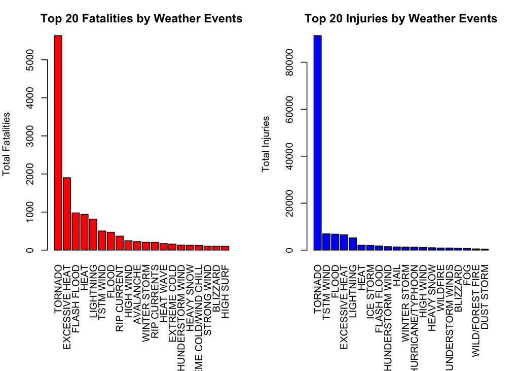

```r
par(mfrow = c(1, 2), mar = c(10, 4, 3, 2), mgp = c(3, 1, 0), cex = 0.8)
barplot(fatalities_20$FATALITIES, las = 3, names.arg = fatalities_20$EVTYPE, main = "Top 20 Fatalities by Weather Events",
    ylab = "Total Fatalities", col = "red")
barplot(injuries_20$INJURIES, las = 3, names.arg = injuries_20$EVTYPE, main = "Top 20 Injuries by Weather Events",
    ylab = "Total Injuries", col = "blue")
```

```r
dev.copy(png,file="barplot_health.png")
```

```r
dev.off()
```

Based on the above graph depiction, TORNADO dominates the FATALITIES

#### Question2: Across the United States, Across the United States, which types of events have the greatest economic consequences?

#### Analysis for calamities that cause Major economic losses

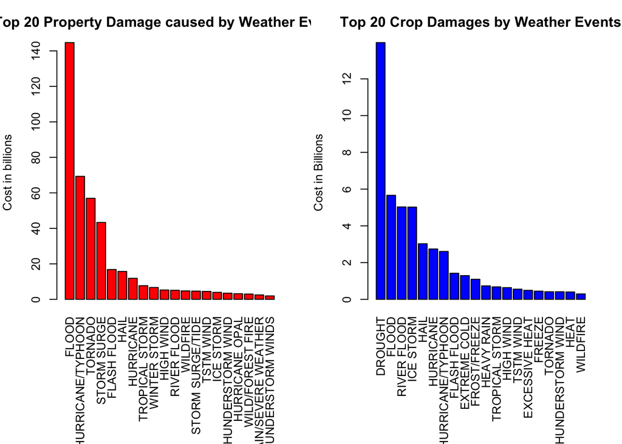

```r
par(mfrow = c(1, 2), mar = c(10, 4, 3, 2), mgp = c(3, 1, 0), cex = 0.8)
barplot(prop_dam20$PROPDMGVAL/(10^9), las = 3, names.arg = prop_dam20$EVTYPE,
    main = "Top 20 Property Damage caused by Weather Events", ylab = "Cost in billions",
    col = "red")
barplot(crop_dam20$CROPDMGVAL/(10^9), las = 3, names.arg = crop_dam20$EVTYPE,
    main = "Top 20 Crop Damages by Weather Events", ylab = "Cost in Billions",
    col = "blue")
```

```r
dev.copy(png,file="barplot_economy.png")
```

```r
dev.off()
```

Based on the above graph depiction, FLOOD dominates the Property losses & DROUGHT dominates the Crop losses